# HW5

Furkan Cetinkaya

1/7/2019

In this assignment, we have to cluster the data with two different clustering approaches, using two different distance measures. First, the data was scaled to be able to perform clustering.

```r
MuskScaled<-scale(MuskData[,-(1:2)])
```

Then, the optimum number of clusters are found using “factoextra” package.

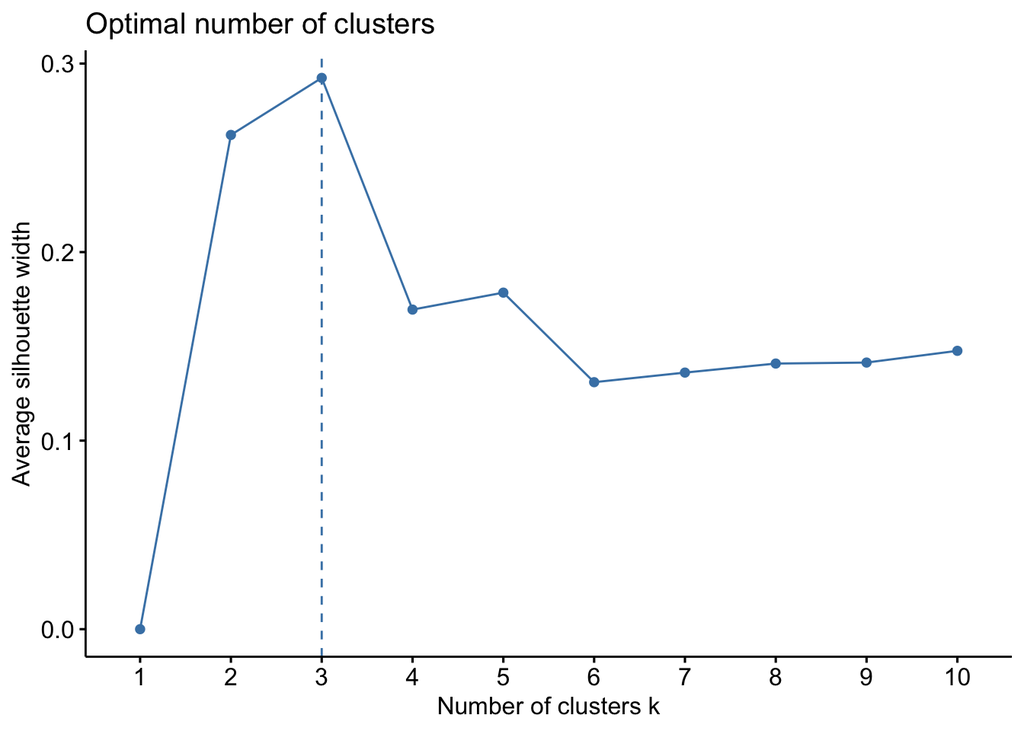

```r
fviz_nbclust(MuskScaled[,-(1:2)], FUN = hcut, method = "silhouette")    ##choose 3 clusters for hcust
```

Optimum number of clusters for hierarchical clustering method is 3. While finding the number of clusters, I used the average silhouttes.

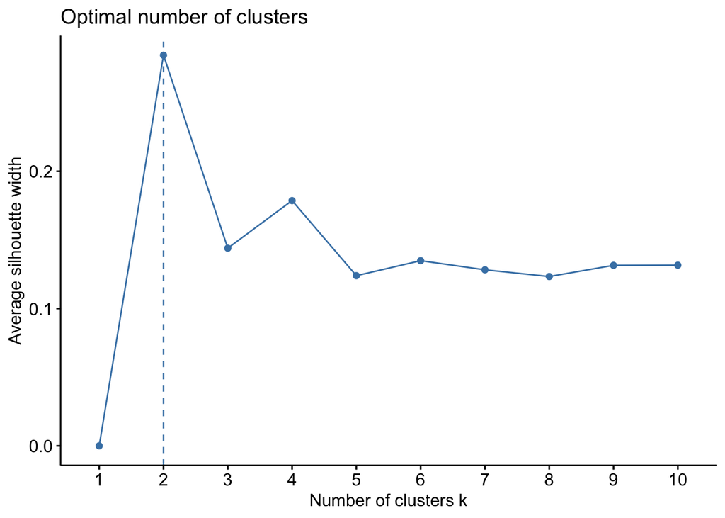

```r
fviz_nbclust(MuskScaled[,-(1:2)], FUN = pam, method = "silhouette")    ##choose 2 clusters for pam
```

Optimum number of clusters for partitioning around medoids method is 2.

Then, I performed clustering using manhattan and euclidian distance measures for pam and hc methods.

```r
pamEuc<-pam(MuskScaled[,-(1:2)], 2, diss=FALSE, metric = c("euclidean"))
pamMan<-pam(MuskScaled[,-(1:2)], 2, diss=FALSE, metric = c("manhattan"))
hcEuc<-hclust(dist(MuskScaled[,-(1:2)], method = "euclidean"), method="ward.D2")
hcMan<-hclust(dist(MuskScaled[,-(1:2)], method = "manhattan"), method="ward.D2")
```

Clustering plots for partitioning around medoids method can be seen below:

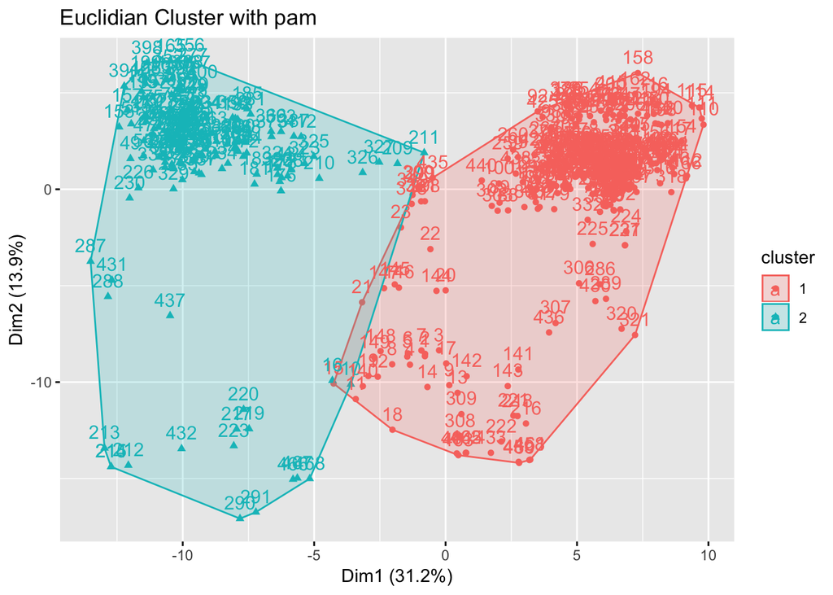

```r
fviz_cluster(pamEuc, data = MuskScaled[,-(1:2)], main = "Euclidian Cluster with pam")
```

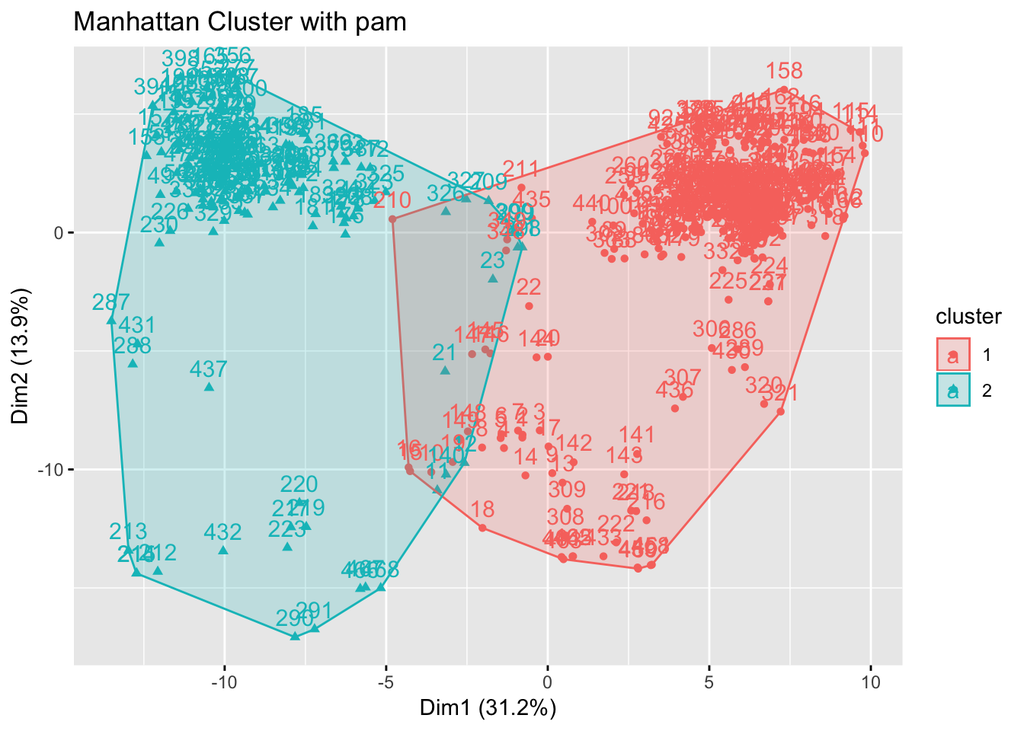

```r
fviz_cluster(pamMan, data = MuskScaled[,-(1:2)], main = "Manhattan Cluster with pam")
```

Clustering plots for HC can be seen below:

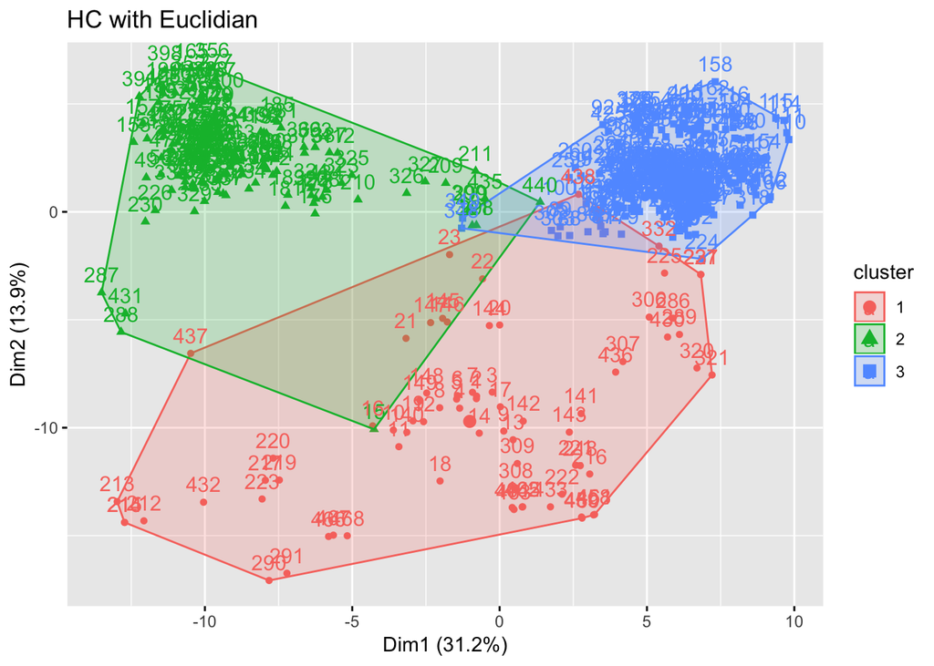

```r
fviz_cluster(list(data = MuskScaled[,-(1:2)] , cluster = cutEuc), main = "HC with Euclidian")
```

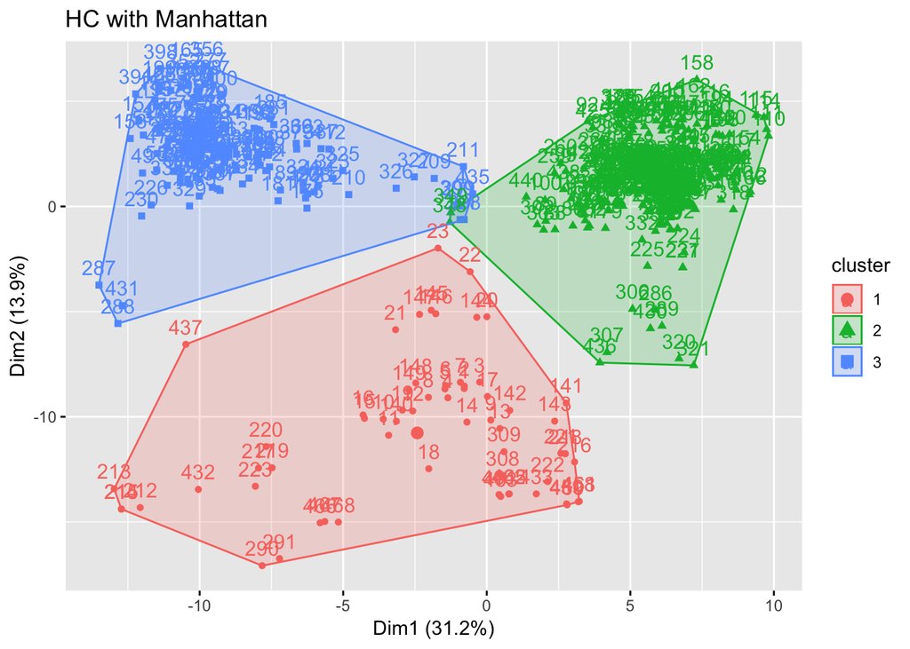

```r
fviz_cluster(list(data = MuskScaled[,-(1:2)] , cluster = cutMan), main = "HC with Manhattan")
```

After clustering, the distances between each instance and the cluster centroid are found. I used manhattan distance if I used manhattan distance when clustering, and euclidian if I used euclidian when clustering.

Then, the mean value of distances for each bag are found to be able to represent the bags as the average of its instace distances to the cluster centroids. So, every bag is represented with 2 matrix with 2 features(number of clusters for pam) and 2 matrix with 3 features(number of clusters for hc).

After bag level representation, I trained lasso logistic regression with 10 fold cross validation on 4 different datasets I have. For each fold, I calculated the area under ROC curves and found the mean value of these areas. Clustering performance can be compared with the area under the ROC curves. Having the area larger means that the data is clustered better. Therefore, the method with the largest area will be the method I would chose.

```r
meanAUC(BagRep1)   #pam with euclidian
```

```
## [1] 0.67875
```

```r
meanAUC(BagRep2)   #pam with manhattan
```

```
## [1] 0.69
```

```r
meanAUC(BagRep3)   #hc with euclidian
```

```
## [1] 0.69
```

```r
meanAUC(BagRep4)   #hc with manhattan
```

```
## [1] 0.7975
```

Since the hierarchical clustering method with manhattan distance has the largers area, it performed the best compared to others. For HC methods, optimum number of clusters was 3. So the best parameters are hieararchical clustering, manhattan distance and 3 clusters.

## Codes

```r
require(data.table)
require(cluster)
require(factoextra)
require(ggplot2)
require(TSdist)
require(TunePareto)
require(pROC)
set.seed(2)
MuskData<-as.data.table(read.csv('/Users/furkancetinkaya/Desktop/ie582/Musk1.csv', header = F))
setnames(MuskData,"V1","Bag class")
setnames(MuskData,"V2","Bag Id")

nrow(unique(MuskData[,1]))   ##2 classes
nrow(unique(MuskData[,2]))   ##92 bags

sum(is.na(MuskData))   ## no missing values

MuskScaled<-scale(MuskData[,-(1:2)])
MuskScaled<-cbind(MuskData[,1:2], MuskScaled)

fviz_nbclust(MuskScaled[,-(1:2)], FUN = hcut, method = "silhouette")    ##choose 3 clusters for hcust
fviz_nbclust(MuskScaled[,-(1:2)], FUN = pam, method = "silhouette")    ##choose 2 clusters for pam

pamEuc<-pam(MuskScaled[,-(1:2)], 2, diss=FALSE, metric = c("euclidean"))       ##pam with different distance measures
pamMan<-pam(MuskScaled[,-(1:2)], 2, diss=FALSE, metric = c("manhattan"))

fviz_cluster(pamEuc, data = MuskScaled[,-(1:2)], main = "Euclidian Cluster")    ##plot for pam
fviz_cluster(pamMan, data = MuskScaled[,-(1:2)], main = "Manhattan Cluster")

hcEuc<-hclust(dist(MuskScaled[,-(1:2)], method = "euclidean"), method="ward.D2")
hcMan<-hclust(dist(MuskScaled[,-(1:2)], method = "manhattan"), method="ward.D2")

cutEuc <- cutree(hcEuc, k = 3)
cutMan <- cutree(hcMan, k = 3)

hcManCent<-apply (MuskScaled[,-c(1,2)], 2, function (x) tapply (x, cutEuc, mean))   ##hc centroid calculation
hcEucCent<-apply (MuskScaled[,-c(1,2)], 2, function (x) tapply (x, cutMan, mean))


plot(hcEuc, cex = 0.6)       ##plot of dendogram
rect.hclust(hcEuc, k = 3, border = 2:5)

plot(hcMan, cex = 0.6)
rect.hclust(hcMan, k = 3, border = 2:5)

DistPamEuc=MuskScaled[,c(1,2)]
DistPamMan=MuskScaled[,c(1,2)]
DistHcEuc=MuskScaled[,c(1,2)]
DistHcMan=MuskScaled[,c(1,2)]
for( i in 1:3){
DistHcEuc=cbind(DistHcEuc,apply(MuskScaled[,-c(1,2)],1,function(x){sqrt(sum(x-hcEucCent[i,])^2)}))   ##distance of instances to cluster centoids
DistHcMan=cbind(DistHcMan, apply(MuskScaled[,-c(1,2)],1,function(x){sum(abs(x-hcManCent[i,]))}))
}
for( i in 1:2){
DistPamEuc=cbind(DistPamEuc,apply(MuskScaled[,-c(1,2)],1,function(x){sqrt(sum(x-pamEuc$medoids[i,])^2)}))
DistPamMan=cbind(DistPamMan,apply(MuskScaled[,-c(1,2)],1,function(x){sum(abs(x-pamMan$medoids[i,]))}))
}

colnames(DistPamEuc)<-c("class","bag id","V1","V2")
colnames(DistPamMan)<-c("class","bag id","V1","V2")
colnames(DistHcEuc)<-c("class","bag id","V1","V2","V3")
colnames(DistHcMan)<-c("class","bag id","V1","V2","V3")

BagPamEuc<-data.table()
BagPamMan<-data.table()
BagHcEuc<-data.table()
BagHcMan<-data.table()


DistPamEuc[,mean1:=mean(V1),by="bag id"]   ##mean calculation bag level representations
DistPamEuc[,mean2:=mean(V2),by="bag id"]
DistPamMan[,mean1:=mean(V1),by="bag id"]
DistPamMan[,mean2:=mean(V2),by="bag id"]
DistHcEuc[,mean1:=mean(V1),by="bag id"]
DistHcEuc[,mean2:=mean(V2),by="bag id"]
DistHcEuc[,mean3:=mean(V3),by="bag id"]
DistHcMan[,mean1:=mean(V1),by="bag id"]
DistHcMan[,mean2:=mean(V2),by="bag id"]
DistHcMan[,mean3:=mean(V3),by="bag id"]

BagRep1<-unique(DistPamEuc[,-c("V1","V2")])
BagRep2<-unique(DistPamMan[,-c("V1","V2")])
BagRep3<-unique(DistHcEuc[,-c("V1","V2","V3")])
BagRep4<-unique(DistHcMan[,-c("V1","V2","V3")])


meanAUC<-function(data){    ##function to calculate mean AUC using 10 fold cross validation with lasso
nofReplications=2
nFolds=10
alpha=1
nlambda=50
train_class=as.factor(data$class)
train = data[, -c(1:2)]
glmnet_alldata = glmnet(as.matrix(train), as.factor(train_class), family="binomial", alpha = alpha, nlambda=nlambda)
indices=generateCVRuns(train_class,nofReplications,nFolds,stratified=TRUE)
lambda_sequence = glmnet_alldata$lambda
cvresult=vector('list',nofReplications*nFolds)
iter=1
for(i in 1:nofReplications) {
  thisReplication=indices[[i]]
  for(j in 1:nFolds){
    testindices=thisReplication[[j]]
    cvtrain=train[-testindices]
    cvtrainclass=train_class[-testindices]
    cvtest=train[testindices]
    cvtestclass=train_class[testindices]
    inner_cv_glmnet_fit = glmnet(as.matrix(cvtrain),as.factor(cvtrainclass),family="binomial", alpha = alpha,lambda=lambda_sequence)
    valid_pred = t(as.matrix(predict(inner_cv_glmnet_fit, as.matrix(cvtest), s = lambda_sequence, type = "class")))
    foldresult=rbindlist(lapply(c(1:length(lambda_sequence)),function(x) { data.table(repl=i,fold=j,lambda=lambda_sequence[x],bag_class=cvtestclass,pred=valid_pred[x,], AUC=auc(roc(cvtestclass, as.numeric(valid_pred[x,]))))}))
    cvresult[[iter]]=foldresult
    iter=iter+1
  }
}
cvresult=rbindlist(cvresult)
cvresultfinal=unique(cvresult[,list(repl,fold,lambda, AUC)])
meanAUC = mean(cvresultfinal$AUC)
return(meanAUC)
}

meanAUC(BagRep1)    ##mean curve areas
meanAUC(BagRep2)
meanAUC(BagRep3)
meanAUC(BagRep4)
```